# Bioinformatics Bootcamp 2026

[figure not shown]

## Schedule

| Date | Time | Activity |
| --- | --- | --- |
| Mon 02/11/2026 | 10:00 to 16:00 | Unix-like systems, bash, connecting to SCWales |
| Tue 03/11/2026 | 10:00 to 16:00 | More bash, scripts, SCWales, using SCWales and slurm |
| Wed 04/11/2026 | 10:00 to 16:00 | Illumina data, BEARCAVE, data processing |
| Thu 05/11/2026 | 10:00 to 16:00 | ANGSD, covariance and distance matrices, heterozygosity, intro to R |
| Fri 06/11/2026 | 10:00 to 16:00 | Maps, PCA’s, NJ trees, Manhattan plots and Rmarkdown |

## Prequisites

- a computer with internet connection
- an account on super-computing Wales
- basic knowledge of DNA and genome structure

## Resources

### Lecture slides

https://drabarlow.github.io/bioinformatics_bootcamp/

### Bootcamp worksheet

https://drabarlow.github.io/bioinformatics_bootcamp/bootcamp_worksheet_2026.html

### Github repo

https://github.com/drabarlow/bioinformatics_bootcamp

## Introductions

### Axel Barlow, Lecturer in Zoology at Bangor University

- Self taught post-PhD
- No proper bioinformatics/computer science background
- Knowledge of `bash` and `R`.

### Johanna Paijmans, Lecturer in Zoology at Bangor University

- Self taught (rebelling against a Linux-expert dad)
- No proper bioinformatics/computer science background
- Knowledge of `bash` and `R`.

## Introductions

[figure not shown]

## Unix-like systems and bash

## Unix

- Operating system developed in 1969 by Bell Labs
- Unix philosophy: *operating system should provide a set of simple tools, each of which performs a limited, well-defined function.*
- Modular (small programs strung together)
- Inter-process communication: “pipes”
- Separate normal and “super” users (`sudo`)
- Hierarchical filesystem
- A shell for executing and combining tools
- The basis of many subsequent OS

[figure not shown]

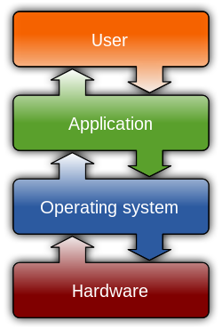

## Unix

[interactive chart not shown]

## Unix-like systems

**Mac OS**

- Released 1984
- Developed from NeXTSTEP, which is developed from Unix
- Proprietary, Apple hardware only

**Linux**

- 21 year old Linus Torvalds coded a Unix inspired OS in 1991
- Free and open source
- The core linux kernel available under many distributions: Ubuntu, Mint, Arch, Android, Tesla, etc.

[figure not shown]

## MS-DOS (Windows)

- Developed by Microsoft, released 1981
- Main OS for IBM PCs in 1980s
- GUI introduced with Windows, released 1985
- Largest market share (70% of PCs)
- Some bioinformatics possible (e.g. `R` typically via `Rstudio`)
- No `bash`
- Encoding of text files is different
- Majority of bioinfomatics software unsupported
- Windows subsystem for linux https://learn.microsoft.com/en-us/windows/wsl/install
- Seamless transfer between `DOS` and `Unix` not yet possible

[figure not shown]

## Windows Subsystem for Linux

- Released in 2016
- Allows installation of Linux distributions (e.g. Ubuntu) within Windows 10/11
- Provides a bash terminal and Linux environment
- Transfer between Windows and Linux filesystems possible
- Essentially WSL is Microsoft’s admittance to Linux superiority

[figure not shown]

## OS comparison

|  | Windows | Mac | Linux |
| --- | --- | --- | --- |
| standard PC functions | yes | yes | yes |
| cost | yes | yes | free |
| hardware choice | yes | no | yes |
| bioinformatics | no | yes | yes |
| HPC | no | no | yes |
| open source | no | no | yes |
| active community | no | no | yes |
| games | yes | no | no |

## Terminal emulators and Bash

[figure not shown]

- Most Unix-like OS (incl Mac) use `bash` or something like it
  - execute standard OS functions and installed programs
  - access filesystem
  - supports bash scripts
  - pipes, auto-completion, loops, wildcards, etc.

## Supercomputing Wales

## Falcon

[figure not shown]

## Falcon

- **Computational nodes**
  - >70x computing nodes with 192 cores + 768 Gb RAM each
  - >8x highmem nodes with 192 cores + 1536 Gb RAM each
  - >18x Nvidia GPU nodes with 2-8 nodes each
- **Storage space**
  - 1192TB (usable) scratch space
  - 457TB of home (redundant) directory space
- **Support**
  - Online documentation https://www.supercomputing.wales/
  - eResearch manager Ade Fewings (a.fewings@bangor.ac.uk)

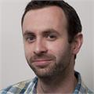

## Falcon usage

- Command-line only (via `ssh`)
- Access through SSH jump host
- File transfer using `scp` or `sftp`
- Job submission using `slurm` job scheduler
- Software installed as `modules`
- No super user access
- **Space & quota**
  - Home directory (small, persistent): 50Gb
  - Scratch space (bigger, temporary): SCW projects, few Tb
  - Variable max active jobs, max 10 in the queue
  - Max 3 day runtime
  - check with `myquota`

## Secure shell (SSH)

[figure not shown]

## SSH via jump host

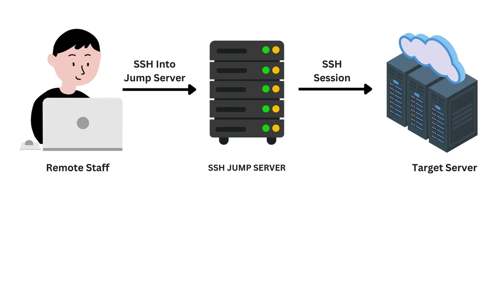

## SSH via jump host

[figure not shown]

## Getting logged on…

**Connecting to the jump host (with MFA)**

```bash
ssh you26usr@ssh.bangor.ac.uk
```

*Note: most UNIX systems do not show anything when you’re typing your password!*

**If successful, connecting to Falcon**

```bash
ssh b.you26usr@falconlogin.cf.ac.uk
```

*Raise your hand if you are having issues* 🙌

## AI

## A brief note on AI in Bioinformatics

- AI tools (LLMs) are becoming increasingly common in bioinformatics (and everywhere else)
- AI lowers the barrier to implementation but it does not remove the need for computational understanding
- Changing workflows: more time on conceptualisation and design. Less time on implementation. Less time on testing. More time on debugging.
- Once you get into higher level bioinformatics, the possibilities are just astronomical

## A brief note on AI in Bioinformatics

[figure not shown]

## A brief note on AI in Bioinformatics

[video not shown]

## A brief note on AI in Bioinformatics

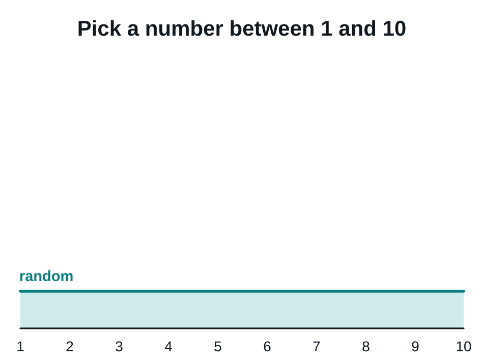

## A brief note on AI in Bioinformatics

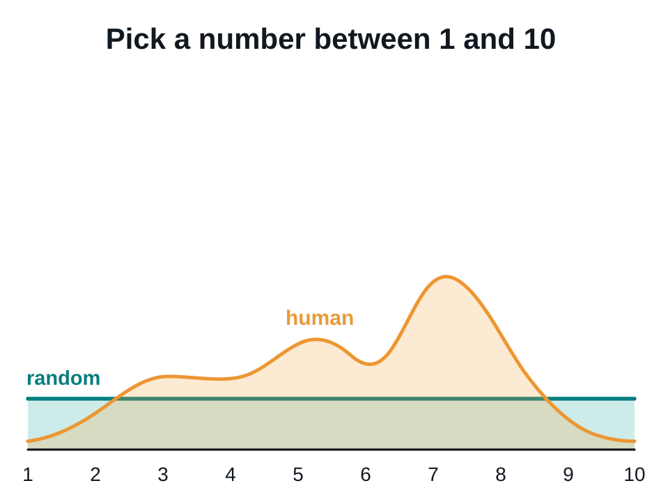

## A brief note on AI in Bioinformatics

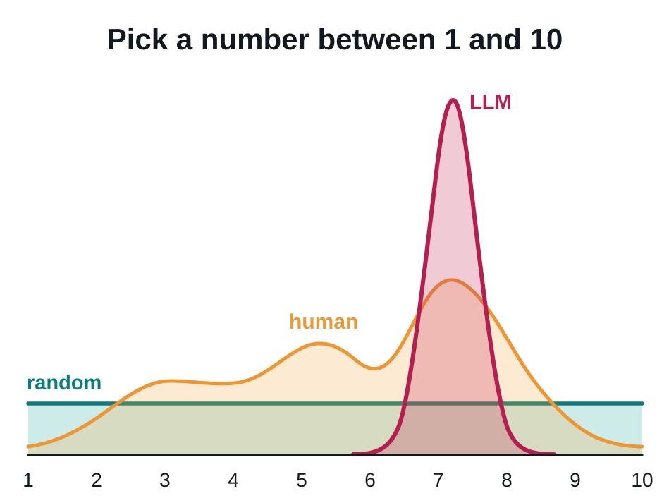

## Filesystem

- `/` [root] is uppermost level of filesystem
- Everything is contained in `/`
- Directories exist within the filesystem, they can contain files and other directories
- We specify a path through this hierarchy using forward-slashes
- Our current directory is called the `working directory`

```bash
/home/b.xlb21brx/
/scratch/b.xlb21brx/
```

- We can navigate through the filesystem (change working directory)
- Or we can specify the patch to directories or files remotely

## Copying files via SCP

[figure not shown]

## Slurm

- Simple Linux Utility for Resource Management: `slurm`
- Free open source job scheduler for linux systems
- Used on 60% of World’s top 500 computers
- Assigns user jobs to computer resources
- Submit to queue
- Short, low-resource jobs move faster through the queue
- Useful tools for scheduling, reporting, etc

[figure not shown]

## Illumina data

## Illumina sequencing platforms

[figure not shown]

## Illumina summary

- The current market leader
- Massive output
- Many applications (genome resequencing, RADseq, transcriptomes, metabarcoding)
- Cheap (£10 per Gb)
- Major limitation is the read length

## Data output

[output not shown]

## Sequencing by synthesis

1. Sample preparation
2. Bind DNA to flowcell
3. Generate clusters
4. Sequencing by synthesis
5. Image analysis

[video not shown]

## Sample preparation

[figure not shown]

*Indexes allow multiple samples to be sequenced at the same time

## Flow cell

[figure not shown]

## Cluster generation

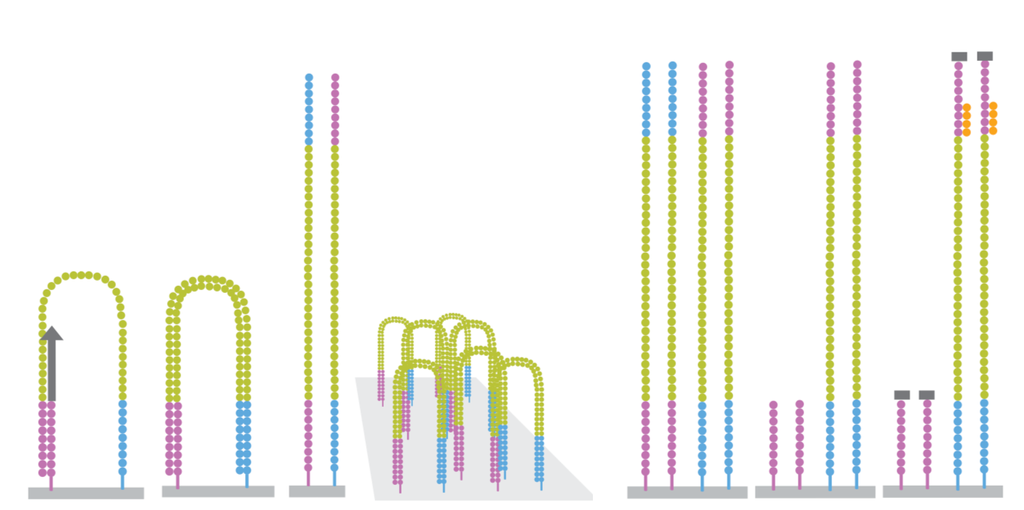

## Sequencing by synthesis

[figure not shown]

## Data analysis (in the machine)

[figure not shown]

## What do we sequence?

[Not an exhaustive list]

- **Whole genome sequencing (pure DNA sample from a single individual)**
- Reduced representation genome data (RADseq, targeted SNPs, single individual)
- Poolseq (multiple individuals)
- Transcriptome (RNA sample from single tissue/individual)
- Metabarcoding (PCR amplicon, multiple individuals/species)
- Metagenomics (whole genomes, multiple individuals/species)

## Whole genome sequencing

Short reads from a single individual can be mapped to a reference genome assembly

[figure not shown]

## Whole genome sequencing

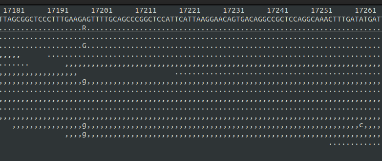

## Our project: adder population genomics

- Adders (*Vipera berus berus*) widespread across northern Eurasia
- Threatened or near-threatened in UK
- Illumina PE data from 47 individuals
- Plus one outgroup (*Vipera berus bosniensis*)
- 12 locations
- **Our tasks**
  - Data format
  - Adapter trimming and read merging
  - Map to reference genome: chr7

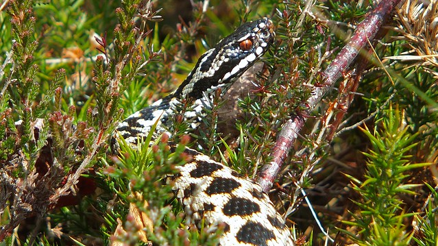

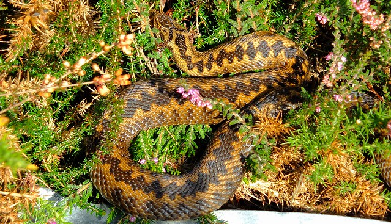

## Adder locations

```
      +-------------+---------------+
      |   Sample    |   Locality    |
      +-------------+---------------+
      | adder01-04  | Leeds         |
      | adder05-08  | Wensleydale   |
      | adder09-12  | Manchester    |
      | adder13-16  | Caerphilly    |
      | adder17-20  | Gouda         |
      | adder21-24  | Stockholm     |
      | adder25-27  | Cheddar       |
      | adder28-31  | Huddersfield  |
      | adder32-35  | Sheffield     |
      | adder36-39  | Leicester     |
      | adder40-43  | Nottingham    |
      | adder44-47  | Stilton       |
      | adderout    | outgroup      |
      +-------------+---------------+
```

## Illumina data processing

## .fastq file format

- fastq is the standard output format for data from Illumina (and other) platforms

```bash
@A00551:758:HKTVJDSX7:4:1101:3595:6872 1:N:0:CCTGAGATGT+GGTCTAGTTG
CTGAATATGGATTTTAATTGAATCCTAAGATATTATAGCATCTTTCACTCCCTGTCCTGTGCATGTCAGA
+
FFFFFFFFFFFFFFFFFFFFFFFFFFFFFFFFFFFFFFFFFFFFFFFFFFFFFFFFFFFFFFFFFFFFFF
```

- **Line 1**: info on sequencer, flowcell, cluster position, indexes (sometimes)
- **Line 2**: called bases
- **Line 3**: a +
- **Line 4**: quality scores on Phred scale
- 10 = 90% accuracy; 20 = 99% accuracy; 30 = 99.9% accuracy
- Recoded as single character: F = 37; ? = 30; 5 = 20; + = 10

## BEARCAVE

## BEARCAVE

- Nikolas Basler, Achim Klittich, Axel Barlow
- An environment for organising, processing, and archiving Illumina data
- BEARCAVE philosophy
  - All users can access all data
  - Avoid data redundancy
  - All samples processed using identical software programs and parameters
  - Incorporates sample metadata
  - Documents results of data processing
  - Easy to use wrapper scripts for programs
  - Publicly available
  - Safeguards in place to ensure consistency
- Consequently BEARCAVE is not for everyone, and has idiosyncrasies in use

## Adapter trimming and read merging

## DNA fragment length distribution

- DNA can be fragmented
- The fragment lengths have a **distribution**

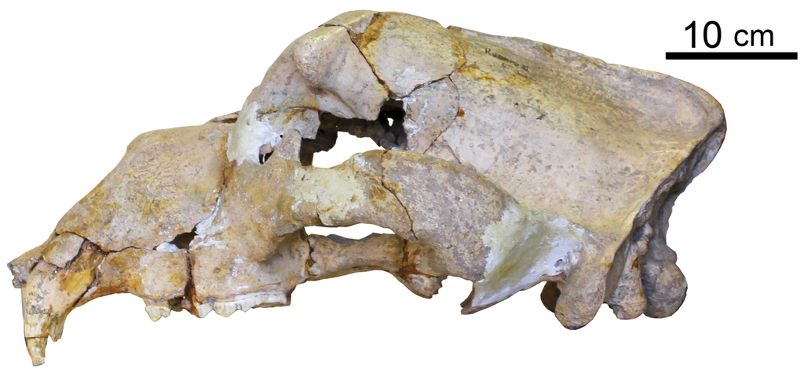

45 ka cave bear (*Ursus kudarensis*)

[figure not shown]

## Effect of insert size

[figure not shown]

## Effect of insert size

[figure not shown]

## Effect of insert size

[figure not shown]

## Effect of insert size

[figure not shown]

## Effect of insert size

[figure not shown]

## Effect of insert size

[figure not shown]

## Adapter trimming

[figure not shown]

## Overlapping reads are merged

[figure not shown]

## BEARCAVE script

- decompress fastqs
- trim adapter seqs using `Cutadapt`
  - 30 bp min length
  - min overlap 1 bp
- merge overlapping read pair using `FLASH`
- recompress files and clean up
- save appropriate log files

**Expected output in** `/BEARCAVE2/trimdata/*processing/`

- merged reads `*_mappable.fastq.gz` [big file]
- unmerged R1 `*_mappable_R1.fastq.gz` [big file]
- unmerged R2 `*_mappable_R2.fastq.gz` [big file]
- trim report `*_trim_report.log` and merge report `*_merge_report.log`

## Cutadapt

[figure not shown]

## FLASH

[figure not shown]

## Mapping

## BEARCAVE mapping script

- decompress fastqs
- merged (SE) and PE data processed separately
  - mapping using `bwa` mem algorithm
  - PCR duplicates identified and removed using `samtools`
  - Reads with poor mapping quality (Q30) removed using `samtools`
- SE and PE data merged
- mapping log file generated
- file cleanup and renaming

**Expected output in** `/BEARCAVE2/mapped*/*processing/`

- mapped filtered data `*.bam` [big file]
- bam index `*.bam.bai`
- mapping log `*_mapping.log`

## bwa

[figure not shown]

## samtools (48,024 citations)

[figure not shown]

## Population genomics using ANGSD

## angsd

- Widely used program
- MANY population genetics analyses possible
- Tends to work directly from bam files (unlike `plink`, `admixtools`, etc)
- MANY filters available
- Genotype likelihood approach is a particular speciality

Allele1|Allele2|prob11|prob12|prob22 |||| A|T|0.05|0.9|0.05

- Several spin off programs that use GLs
  - `NGSadmix`
  - `PCangsd`
  - `NGSrelate`
  - `realSFS`

## angsd website

[interactive chart not shown]

## angsd paper

[figure not shown]

## Analyses

**Covariance matrix**

- All indviduals
- Allele frequency covariance matrix
- Used for PCA

**Distance matrix**

- All individuals
- absolute genetic distance between populations
- used as input for NJ algorithm

**Heterozygosity**

- Your single adder
- Calculate GLs, ML estimation of SFS along a sliding window using `realSFS`

## Intro to R

## What is `R`

- `R` was born from `S` in the Bell labs in 1992
- Statistical analysis
- Data visualisation
- Free and open source
- Linux, Mac, Windows
- Many additional packages
- Several GUIs e.g. `Rstudio`
- Graphics (even interactive), text documents, websites
- This presentation!

[figure not shown]

## `R` from a heretic and a pragmatist

*(guess who is who)*

**Most people disagree (in some cases strongly)**

- Base `R` is really good!
- `R` ≠ `Rstudio`
- `tidyverse` is not the way to teach `R` to beginners
- Data doesn’t have to be `tidy`
- `ggplot2` code is restrictive
- It’s boring if everyone’s graphs look the same
- It’s OK to type commands directly into the terminal
- It’s OK to modify a raw data file
- It’s OK to combine other tools and languages

## How `R` works

*“Everything is an object; everything that happens is a function”*

## How `R` works

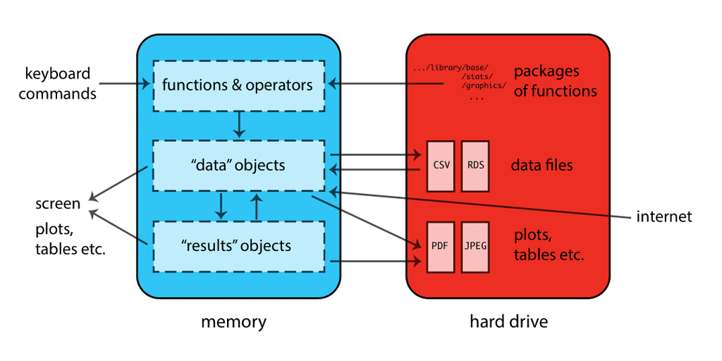

## Objects and functions

**Objects**

- Contain data and results
- Created with `<-`
- Stored in active memory
- Names include letters numbers _ .
- Names must begin with a letter

**Functions**

- Carry out operations on objects
- Often generates new objects
- `function()`
- `?function`, `example(function)`

## Data structures: vector and matrix

**Vector**

- List of values of the same type
- Numbers, strings, or logical values
- Can be generated using `c()`
- Indexing vector objects `my_vector[]`

**Matrix**

- 2D data of same type in rows and columns
- Indexing matrix objects `my_matrix[row, column]`

## Data structures: dataframe and list

**Dataframe**

- Rectangular “table”
- Mixture of data types
- Set of vectors of equal length
- Extract columns with `$`, which can then be indexed like vectors

**List**

- Set of components with different structures
- Extract named components with `$`

## Data structures: as shapes

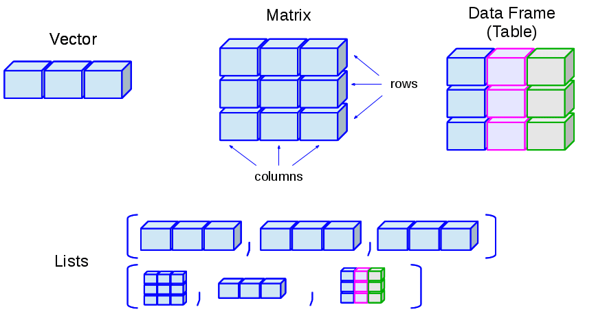

## `Rstudio`

- GUI for `R`
- Preferred by many
- Linked to `tidyverse`
- Linked to `R markdown`
- Version control (`git`) and other development tools

## `Rstudio`

[figure not shown]

## Population genetics: PCA

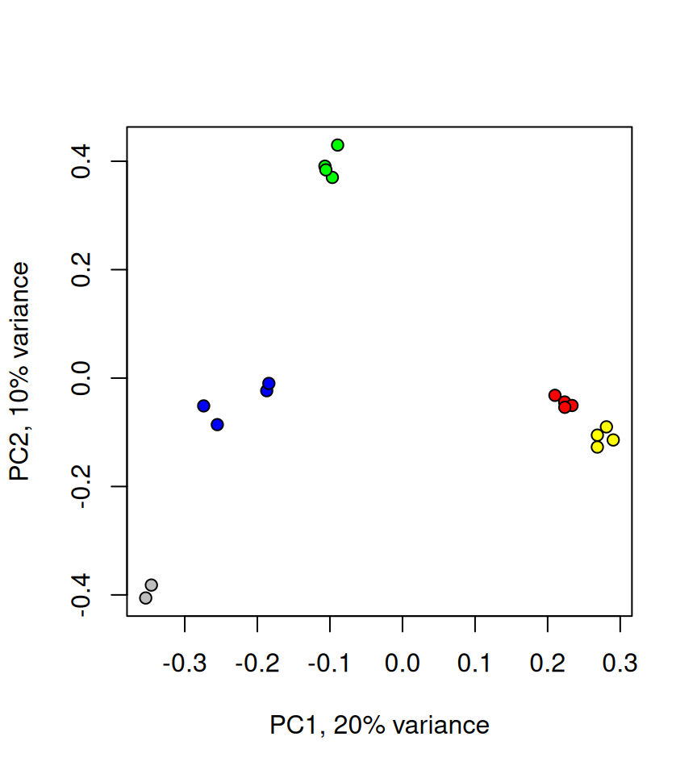

## Population genetics

## Population genetics: Neighbour-joining clustering

- Input is distance matrix
- Neighbour joining algorithm
- Clusters based on genetic similarity
- Rooted using outgroup
- Requires `ape` library
- Basic estimate of phylogeny

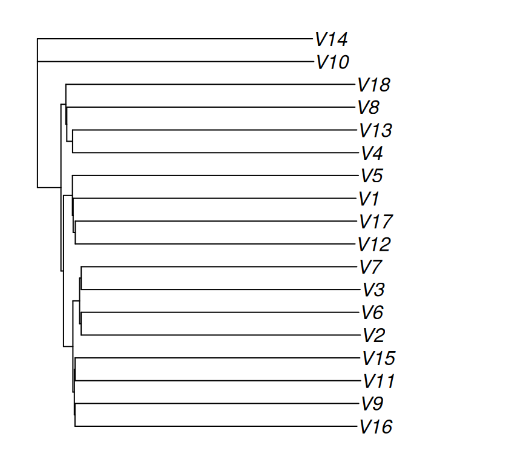

## Heterozygosity

- Input is sliding window estimates of heterozygous sites

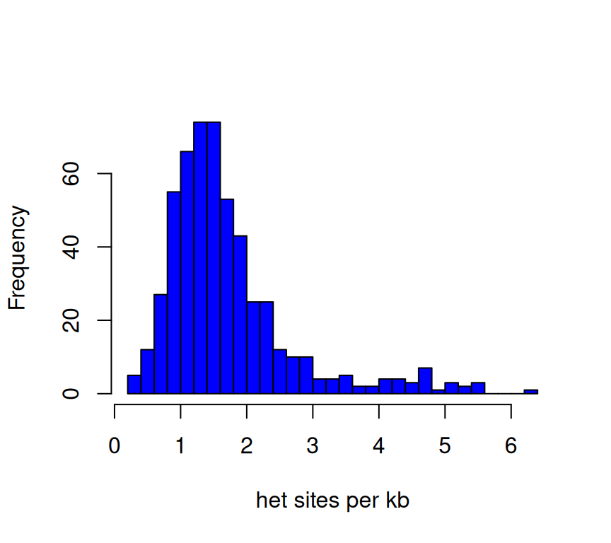

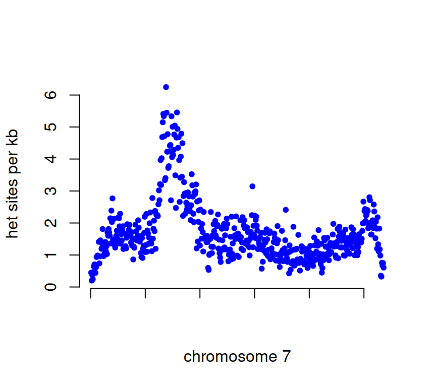

## Rmarkdown

## Rmarkdown

- Dynamic documents in Rstudio
- Combine text, code, and results
- Publishers are increasingly asking for reproducible code capsules

## Reproducability

[interactive chart not shown]

## Rmarkdown example

[interactive chart not shown]

## That’s all folks!

**See you next year :)**